# Analysis of longitudinal data

```r
date()
```

```
## [1] "Mon Dec 12 15:37:25 2022"
```

```r
library(dplyr)
```

```r
library(tidyr)
library(ggplot2)
library(rstatix)
library(ggpubr)
library(lme4)
```

## Analysis of Longitudinal Data I: Graphical Displays and Summary Measure Approach

```r
RATSL <- read.table("./data/RATSL.txt", header=TRUE)
# Factor variables ID and Group
RATSL$ID <- factor(RATSL$ID)
RATSL$Group <- factor(RATSL$Group)

# Glimpse the data
glimpse(RATSL)
```

```
## Rows: 176
## Columns: 5
## $ ID     <fct> 1, 2, 3, 4, 5, 6, 7, 8, 9, 10, 11, 12, 13, 14, 15, 16, 1, 2, 3,~
## $ Group  <fct> 1, 1, 1, 1, 1, 1, 1, 1, 2, 2, 2, 2, 3, 3, 3, 3, 1, 1, 1, 1, 1, ~
## $ WD     <chr> "WD1", "WD1", "WD1", "WD1", "WD1", "WD1", "WD1", "WD1", "WD1", ~
## $ Weight <int> 240, 225, 245, 260, 255, 260, 275, 245, 410, 405, 445, 555, 470~
## $ Time   <int> 1, 1, 1, 1, 1, 1, 1, 1, 1, 1, 1, 1, 1, 1, 1, 1, 8, 8, 8, 8, 8, ~
```

```r
# Check the column names
names(RATSL)
```

```
## [1] "ID"     "Group"  "WD"     "Weight" "Time"
```

```r
# Look at the structure of dataset
str(RATSL)
```

```
## 'data.frame':    176 obs. of  5 variables:
##  $ ID    : Factor w/ 16 levels "1","2","3","4",..: 1 2 3 4 5 6 7 8 9 10 ...
##  $ Group : Factor w/ 3 levels "1","2","3": 1 1 1 1 1 1 1 1 2 2 ...
##  $ WD    : chr  "WD1" "WD1" "WD1" "WD1" ...
##  $ Weight: int  240 225 245 260 255 260 275 245 410 405 ...
##  $ Time  : int  1 1 1 1 1 1 1 1 1 1 ...
```

```r
# Print out summaries of the variables
summary(RATSL)
```

```
##        ID      Group       WD                Weight           Time
##  1      : 11   1:88   Length:176         Min.   :225.0   Min.   : 1.00
##  2      : 11   2:44   Class :character   1st Qu.:267.0   1st Qu.:15.00
##  3      : 11   3:44   Mode  :character   Median :344.5   Median :36.00
##  4      : 11                             Mean   :384.5   Mean   :33.55
##  5      : 11                             3rd Qu.:511.2   3rd Qu.:50.00
##  6      : 11                             Max.   :628.0   Max.   :64.00
##  (Other):110
```

The dataset RATSL is a long format version of data from a nutrition study conducted in three groups of rats. The groups were put on different diets, and each animal’s body weight (grams) was recorded repeatedly (approximately) weekly, except in week seven when two recordings were taken) over a 9-week period.

The dataset has 176 rows and 5 columns (ID, group, weight, and day in borth character and integer formats).

## Plot the RATSL data

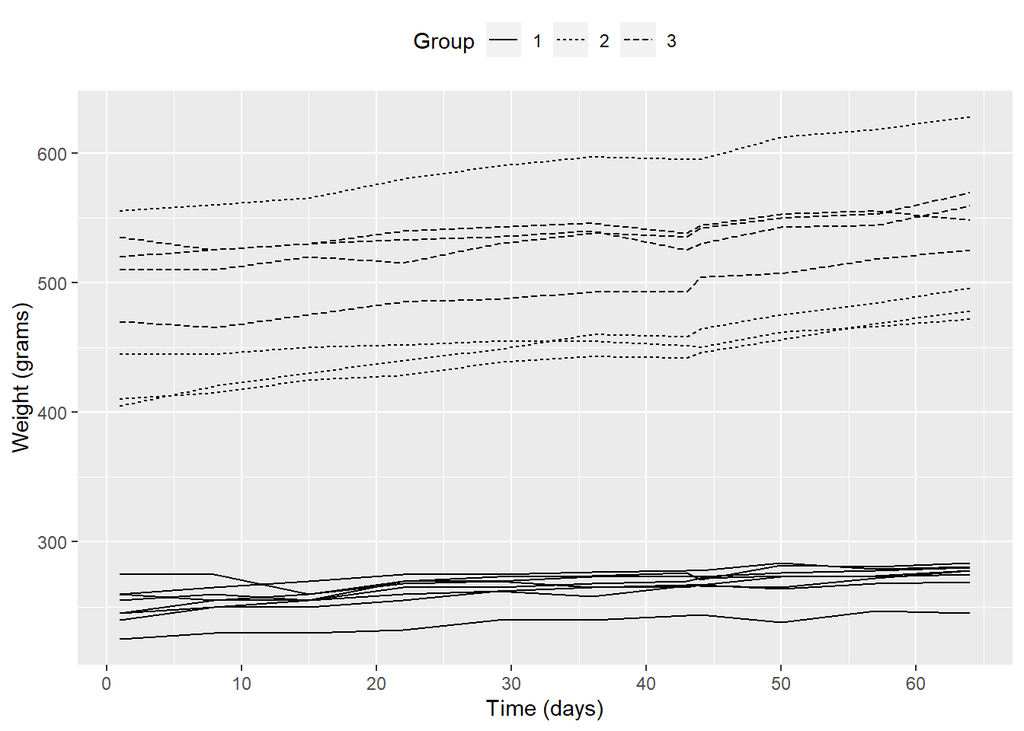

```r
# Plot the data
ggplot(RATSL, aes(x = Time, y = Weight, group = ID)) +
  geom_line(aes(linetype=Group)) +
  scale_x_continuous(name = "Time (days)", breaks = seq(0, 60, 10)) +
  scale_y_continuous(name = "Weight (grams)") +
  theme(legend.position = "top")
```

## Summary graph

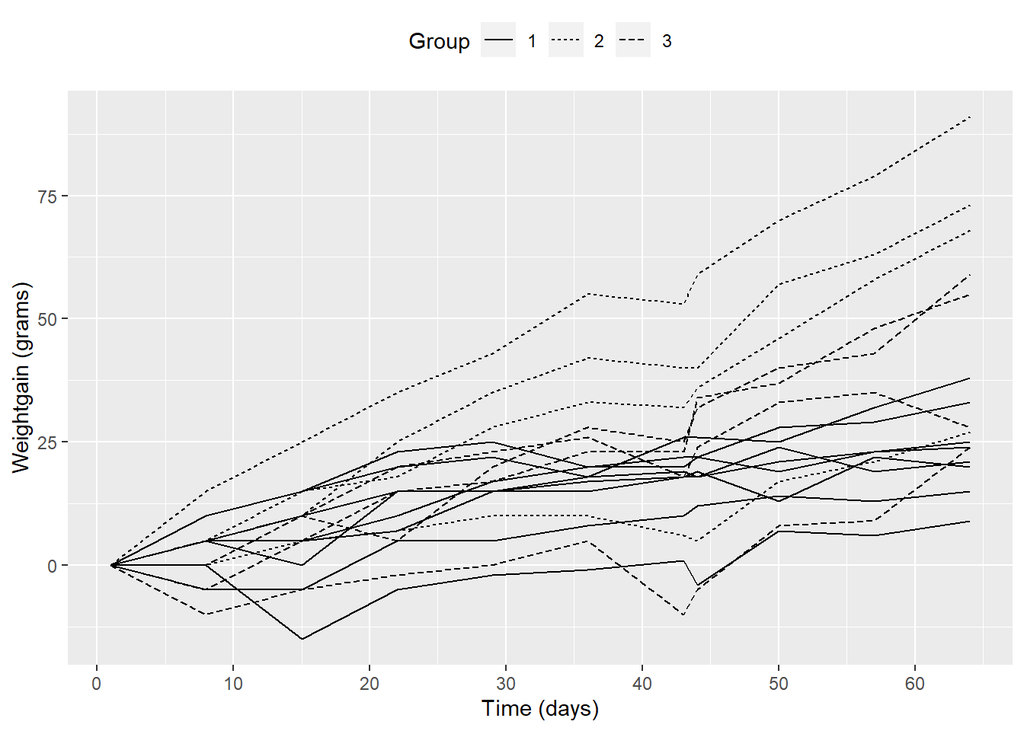

```r
# Calculate the weightgain
RATSL <-
  RATSL %>%
  group_by(ID) %>%
  mutate(Weightgain = Weight - Weight[Time == 1] ) %>%
  ungroup()

# Plot the weightgain
ggplot(RATSL, aes(x = Time, y = Weightgain, group = ID)) +
  geom_line(aes(linetype=Group)) +
  scale_x_continuous(name = "Time (days)", breaks = seq(0, 60, 10)) +
  scale_y_continuous(name = "Weightgain (grams)") +
  theme(legend.position = "top")
```

```r
# Summary data with mean and standard error of weightgain by group and time
RATSS <- RATSL %>%
  group_by(Group, Time) %>%
  summarise( mean = mean(Weightgain), se = sd(Weightgain) ) %>%
  ungroup()
```

[output not shown]

```r
# Glimpse the data
glimpse(RATSS)
```

```
## Rows: 33
## Columns: 4
## $ Group <fct> 1, 1, 1, 1, 1, 1, 1, 1, 1, 1, 1, 2, 2, 2, 2, 2, 2, 2, 2, 2, 2, 2~
## $ Time  <int> 1, 8, 15, 22, 29, 36, 43, 44, 50, 57, 64, 1, 8, 15, 22, 29, 36, ~
## $ mean  <dbl> 0.000, 4.375, 3.750, 11.250, 14.000, 14.375, 16.750, 16.625, 18.~
## $ se    <dbl> 0.000000, 4.955156, 10.264363, 8.988087, 8.734169, 7.308263, 7.7~
```

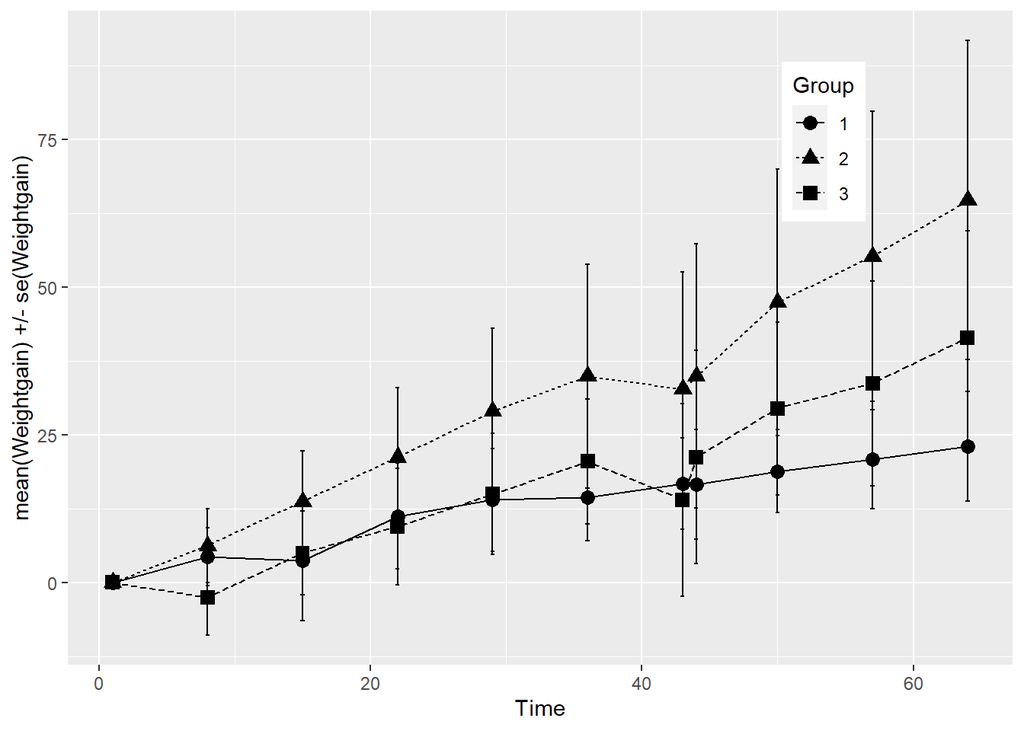

```r
# Plot the mean profiles
ggplot(RATSS, aes(x = Time, y = mean, linetype = Group, shape = Group)) +
  geom_line() +
  geom_point(size=3) +
  geom_errorbar(aes(ymin=mean-se, ymax=mean+se, linetype="1"), width=0.3) +
  theme(legend.position = c(0.8,0.8)) +
  scale_y_continuous(name = "mean(Weightgain) +/- se(Weightgain)")
```

Based on the graph, group 2 seems to have gained most weight in the study period.

## Checking for outliers

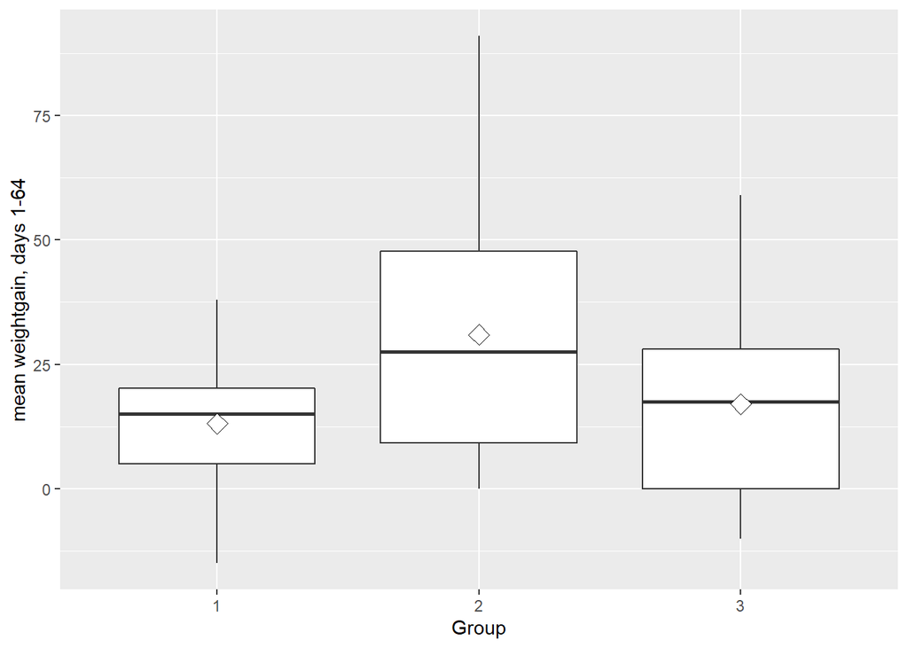

```r
# Draw a boxplot of the mean weightgain versus group
ggplot(RATSL, aes(x = Group, y = Weightgain)) +
  geom_boxplot() +
  stat_summary(fun = "mean", geom = "point", shape=23, size=4, fill = "white") +
  scale_y_continuous(name = "mean weightgain, days 1-64")
```

No outliers detected.

## T-test and Anova

```r
# Pairwise t-test comparisons
pwc <- RATSL %>%
  pairwise_t_test(Weightgain ~ Group, p.adjust.method = "bonferroni")
pwc
```

```
## # A tibble: 3 x 9
##   .y.        group1 group2    n1    n2            p p.signif      p.adj p.adj.~1
## * <chr>      <chr>  <chr>  <int> <int>        <dbl> <chr>         <dbl> <chr>
## 1 Weightgain 1      2         88    44 0.0000000434 ****     0.00000013 ****
## 2 Weightgain 1      3         88    44 0.206        ns       0.619      ns
## 3 Weightgain 2      3         44    44 0.000157     ***      0.000471   ***
## # ... with abbreviated variable name 1: p.adj.signif
```

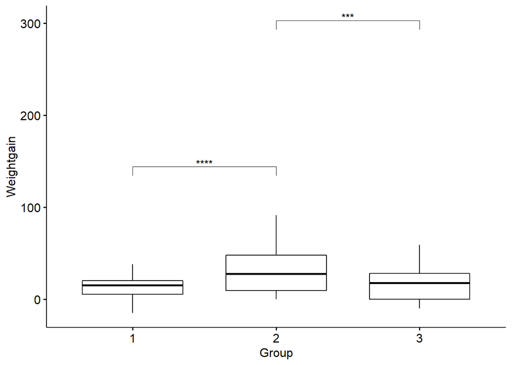

```r
# Visualization: box plots with p-values
pwc <- pwc %>% add_xy_position(x = "Group", step.increase = 1)
ggboxplot(RATSL, x = "Group", y = "Weightgain") +
  stat_pvalue_manual(pwc, hide.ns = TRUE)
```

```r
# Fit the linear model with the mean as the response
fit <- lm(Weightgain~Group, data = RATSL)
summary(fit)
```

```
##
## Call:
## lm(formula = Weightgain ~ Group, data = RATSL)
##
## Residuals:
##     Min      1Q  Median      3Q     Max
## -30.955 -13.091   1.909   8.920  60.045
##
## Coefficients:
##             Estimate Std. Error t value Pr(>|t|)
## (Intercept)   13.091      1.800   7.275 1.16e-11 ***
## Group2        17.864      3.117   5.731 4.34e-08 ***
## Group3         3.955      3.117   1.269    0.206
## ---
## Signif. codes:  0 '***' 0.001 '**' 0.01 '*' 0.05 '.' 0.1 ' ' 1
##
## Residual standard error: 16.88 on 173 degrees of freedom
## Multiple R-squared:  0.1615, Adjusted R-squared:  0.1518
## F-statistic: 16.66 on 2 and 173 DF,  p-value: 2.425e-07
```

```r
# Compute the analysis of variance table for the fitted model with anova()
anova(fit)
```

```
## Analysis of Variance Table
##
## Response: Weightgain
##            Df Sum Sq Mean Sq F value    Pr(>F)
## Group       2   9493  4746.3  16.656 2.425e-07 ***
## Residuals 173  49299   285.0
## ---
## Signif. codes:  0 '***' 0.001 '**' 0.01 '*' 0.05 '.' 0.1 ' ' 1
```

Based on the pairwise t-tests and anova, there seems to be a significant difference in weight gain between groups 1 and 2, and 2 and 3.